# EFBMC - Elastic Functional Bayesian Model Calibration

Example notebook demonstrating workflow for EFBMC. We will demonstrate this method calibrating one experiment from a Z-machine experiment in which we want to know the parameters of the Equation of State Model of Platinum.

Code locations are available below:

1. [impala](https://github.com/sandialabs/impala_matlab)
2. [fdasrvf](https://github.com/jdtuck/fdasrvf_MATLAB)
3. [mvBayes](https://github.com/sandialabs/mvbayes_matlab)
4. [BASS](https://github.com/sandialabs/bass_matlab)

Other surrogate models:

1. [BayesPPR](https://github.com/sandialabs/bayesppr_matlab)

For questions please contact

J. Derek Tucker

Statistical Sciences - 5573

jdtuck@sandia.gov

505-284-8415

[figure not shown]

First we need to set up paths, note this assumes you have run buildtool in the fdasrvf_MATLAB directory first to compile the mex files

```matlab
clc; clear
addpath(genpath('/Users/jdtuck/Documents/Research/fdasrvf/MATLAB/fdasrvf_MATLAB'))
addpath(genpath('/Users/jdtuck/Documents/Research/mvbayes_matlab'))
addpath(genpath('/Users/jdtuck/Documents/Research/impala_matlab'))
addpath('/Users/jdtuck/Documents/Research/bayesppr_matlab/')
addpath('/Users/jdtuck/Documents/Research/BASS_matlab/')
```

## Data Pre-processing

Next we load in the training data from the computer model and extract the simulation parameters. We will also set a path to save the results

```matlab
data_path = '/Users/jdtuck/Documents/Data/zbmc';
buildpath = fullfile(data_path,'PlatinumBMC_May2023/Vinet');
simulations = readmatrix(fullfile(buildpath,'build1','lhs_10000bp_5500res.txt'));
sim_time = readmatrix(fullfile(buildpath,'build1','time.out'),'FileType','text');

a = [3,4,5,6,7,8,9,10,11,12];
sim_variables = simulations(:,a);
p = size(sim_variables, 2);
```

Next we will load in the experiment we wish to calibrate

```matlab
path = fullfile(buildpath,'suite');
expfiles = importdata(fullfile(path,'VISARFileNames.txt'));
expnums = 1;

[f,n,e] = fileparts(expfiles{1});
f2 = fileparts(f);
vdata = readmatrix(fullfile(path,f2,[n,e]));
egrid = vdata(:,1);
edata = vdata(:,2);
```

For preprocesing we will interpolate the curves to 100 points. Reduces computational time.

```matlab
M1 = 1;
N1 = 500;
M = 100;
time_new = linspace(sim_time(M1), sim_time(N1), M)';
f_sim = zeros(M, size(simulations,1));
for i = 1:size(simulations,1)
    f_sim(:,i) = makima(sim_time(M1:N1),simulations(i,(M1+a(end)):(N1+a(end))),time_new);
end

edata = makima(egrid,edata,time_new);
egrid = time_new;
```

Look at the original data with the experiment overlaid

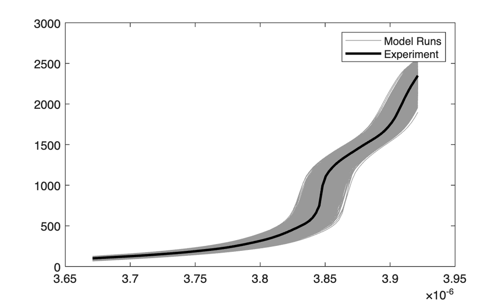

```matlab
figure()
plot(time_new, f_sim(:,1), 'Color', [0.6, 0.6, 0.6])
hold on
plot(time_new, edata, 'k', 'LineWidth',2)
plot(time_new, f_sim, 'Color', [0.6, 0.6, 0.6])
plot(time_new, edata, 'k', 'LineWidth',2)
legend('Model Runs', 'Experiment')
```

## Elastic Functional Alignment

We will now align the computer model output to the experiment. We will need the aligned data ftilde_train and the shooting vectors vv_train. Additionally we will need the shooting vector for the experiment. In this case, since we are aligning to the experiment warping function will be identity () and then the corresponding shooting vector vv_obs.

There is the option of the parameter lam in multiple_align_functions that restricts the amount of alignment. In some cases we will set this to a small value (e.g., 0.01) to remove heteroskedacity from the warping functions.

```matlab
tt = linspace(0,1,M)';
out = fdawarp(f_sim,tt);
lam = 0.01;
out = out.multiple_align_functions(edata,lam,parallel=true);
```

lambda = 0.01

```matlab
gam_train = out.gam;
vv_train = gam_to_h(gam_train);
ftilde_train = out.fn;
qtilde_train = out.qn;
ftilde_obs = out.fmean;

gam_obs = linspace(0, 1, M);
vv_obs = gam_to_h(gam_obs');
```

We will now plot the alignment results. First is the aligned functions.

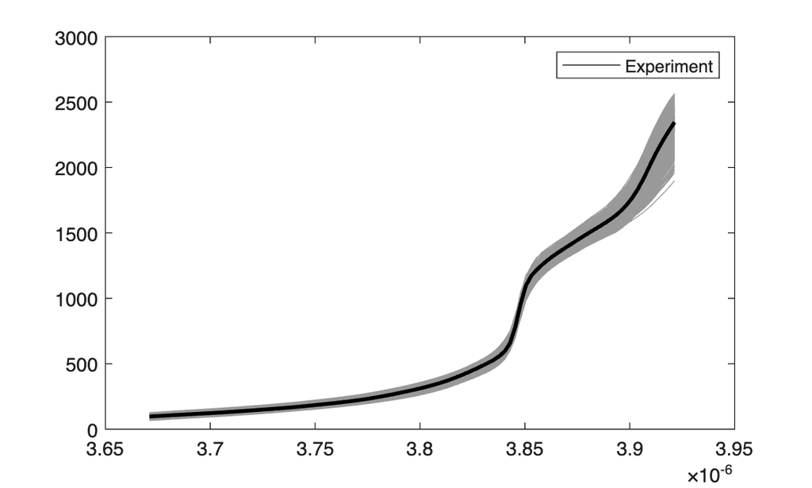

```matlab
figure()
plot(time_new, ftilde_obs, 'k')
hold on
plot(time_new, ftilde_train, 'Color', [0.6, 0.6, 0.6])
plot(time_new, ftilde_obs, 'k', 'LineWidth',2)
legend('Experiment')
```

Then the corresponding warping functions

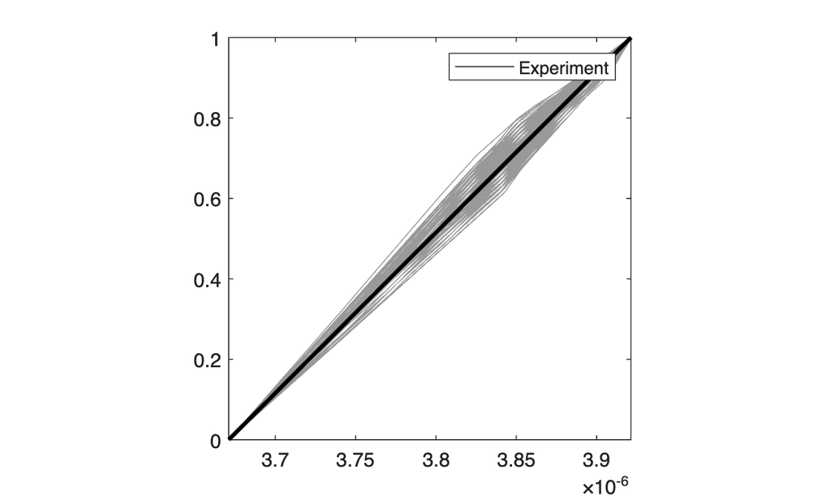

```matlab
figure()
plot(time_new, gam_obs, 'k')
hold on
plot(time_new, gam_train', 'Color', [0.6, 0.6, 0.6])
plot(time_new, gam_obs, 'k', 'LineWidth',2)
axis square
legend('Experiment')
```

and the corresponding shooting vectors

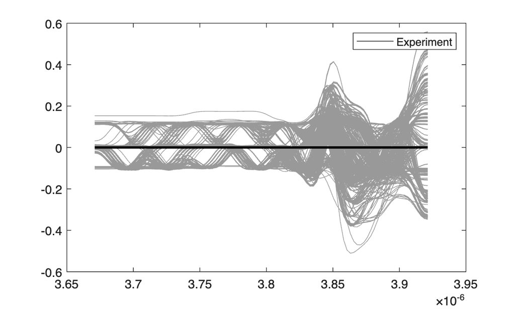

```matlab
figure()
plot(time_new, vv_obs, 'k')
hold on
plot(time_new, vv_train', 'Color', [0.6, 0.6, 0.6])
plot(time_new, vv_obs, 'k', 'LineWidth',2)
legend('Experiment')
```

## Surrogate Model Fitting

The choice of nBasis here is made from exploratory data analysis. It can also be chosen based on the percentage of variance explained from the functional principal component analysis (fPCA) decomposition. The parameter in mvBayes do perform this is propVarExplained.

```matlab
emu_ftilde = mvBayes(@bppr, sim_variables, ftilde_train','idxSamplesArg', 'mcmc_use', 'residSDExtract', @(x) sqrt(x.samples.s2));
```

Start

```matlab
emu_vv = mvBayes(@bppr, sim_variables, vv_train','idxSamplesArg', 'mcmc_use', 'residSDExtract', @(x) sqrt(x.samples.s2));
```

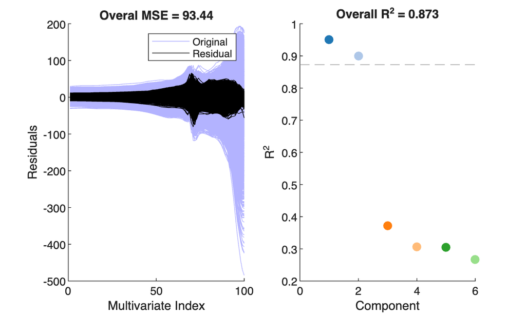

```matlab
emu_ftilde.plot();
```

Lets evaluate the shooting vector emulator

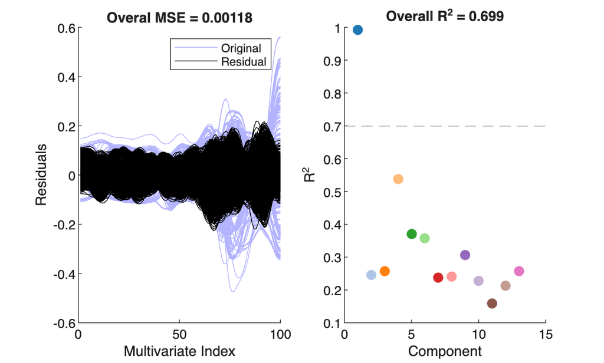

```matlab
emu_vv.plot();
```

## Bayesian Model Calibration

We will now set up impala to perform the calibration. First we need to setup the parameter names and bounds on the parameters. impala sets uniform priors on the parameters based on their bounds.

```matlab
input_names = {'rho','B0','BP0','Y0','A','floort','sampt','dt','ucon','ulin'};

for i = 1:length(input_names)
    bounds.(input_names{i}) = [min(sim_variables(:,i)), max(sim_variables(:,i))];
end
```

We will no set up the calibration object and add the experimental data for the aligned data and shooting vectors. impala is set up to run multiple chains and do annealing so we set up a temperature ladder of 20 chains. We also set the chains to run for 4000 samples with a burn in of 2000 samples. The last line runs the calibration.

```matlab
setup = CalibSetup(bounds, @cf_bounds);

model_ftilde = ModelmvBayes(emu_ftilde, input_names);
model_vv = ModelmvBayes(emu_vv, input_names);

setup.addVecExperiments(edata', model_ftilde, 0.01, 20, ones(1,M));
setup.addVecExperiments(vv_obs', model_vv, 0.01, 20, ones(1,M));
setup.setTemperatureLadder(1.05.^(0:19));
setup.setMCMC(4000,2000,1,10);
out = calibPool(setup);
```

```matlab
uu = 2500:2:4000;

theta = tran_unif(squeeze(out.theta(uu,1,:)), setup.bounds_mat, fieldnames(setup.bounds));
ftilde_pred_obs = setup.models{1}.eval(theta);
vv_pred_obs = setup.models{2}.eval(theta);
gam_pred_obs = h_to_gam(vv_pred_obs');
```

Now we will look at the likelihood and chains to make sure the MCMC chains are stable and have converged

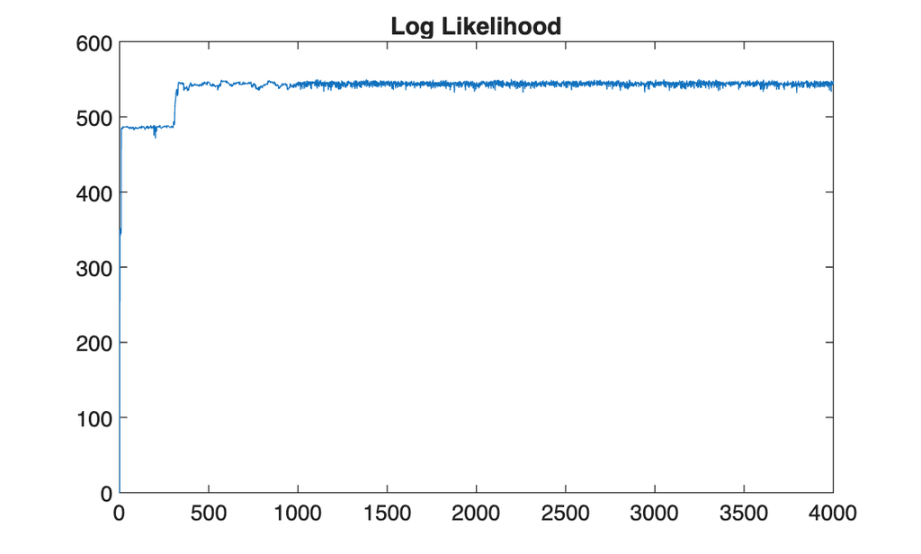

```matlab
figure()
plot(out.llik)
title('Log Likelihood')
```

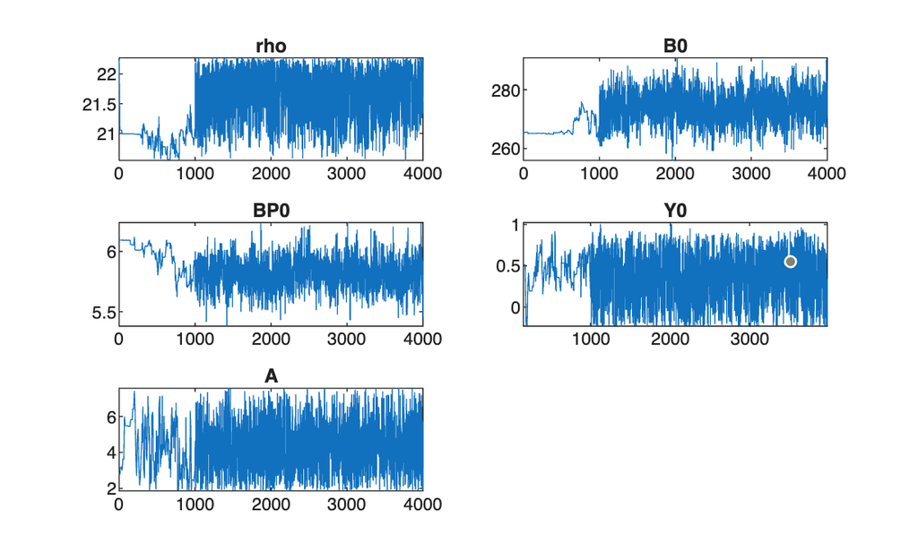

```matlab
input_names2 = input_names([1,2,3,4,5]);

figure()
nplots = length(input_names2);
ns1 = ceil(sqrt(nplots));
ns2 = round(sqrt(nplots));
for i = 1:nplots
    subplot(ns1, ns2, i)
    plot(out.theta_native.(input_names2{i}))
    title(input_names2{i})
end
```

Next we will look at convergence diagnostics of ESS and $\hat R$.

```matlab
[ess,tau,ess_all,tau_all]=ESS(out.theta(uu,1,:),0,0,0);
fprintf('ESS: %f\n',ess)
```

ESS: 238.292356 ESS: 259.530020 ESS: 176.088204 ESS: 286.531363 ESS: 498.184661 ESS: 522.579604 ESS: 252.571989 ESS: 224.774925 ESS: 316.404261 ESS: 249.009468

```matlab
chains = permute(out.theta(uu,:,:), [1,3,2]);
[R,y1,y2]=mcmcgr(chains,.05);
fprintf('Rhat: %f\n',R)
```

Rhat: 1.013421 Rhat: 1.010640 Rhat: 1.023536 Rhat: 1.014920 Rhat: 1.012968 Rhat: 1.005505 Rhat: 1.006760 Rhat: 1.025650 Rhat: 1.011013 Rhat: 1.024661

Examine the pair plot of the parameters. The diagonal contains the posterior distributions of the parameters. The off diagonal is the dependence. The dots are colored by how they appear in the chain (blue is early and red is late). This also helps determine if the chains are mixing well.

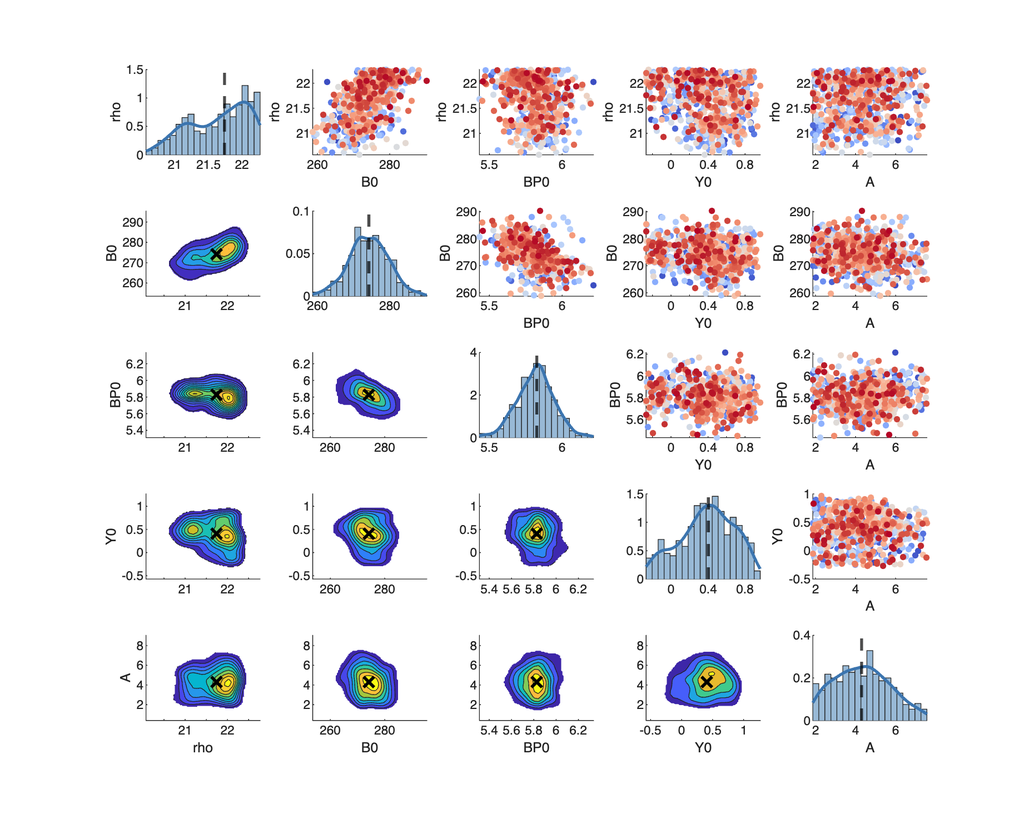

```matlab
fig = figure(104);
fig.Position = [100 100 1000 800];
parmat_array = zeros(length(uu),numel(input_names2));
for i = 1:numel(input_names2)
    parmat_array(:,i) = out.theta_native.(input_names2{i})(uu);
end
pair_plot(parmat_array, input_names2);
```

Next we are going to evaluate the surrogate model at the calibrate parameters for the entire posterior distribution. They gray curves are the computer model, blue curves are the calibrated surrogate curves, and black is the experiment.

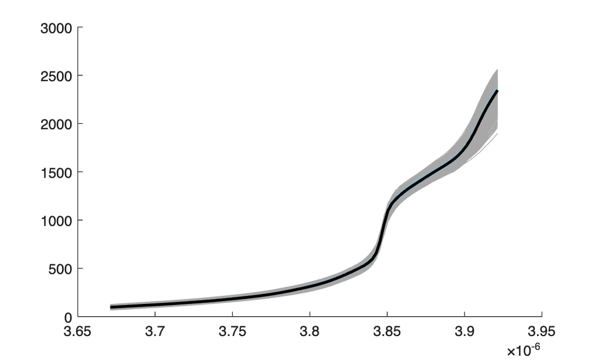

```matlab
figure()
clf
hold on
plot(time_new, ftilde_train, 'Color', [0.66,0.66,0.66])  %light grey
plot(time_new, ftilde_pred_obs, 'Color', [0.58,0.70,0.75])  %light blue
plot(time_new, ftilde_obs, 'k', 'Linewidth', 2)
```

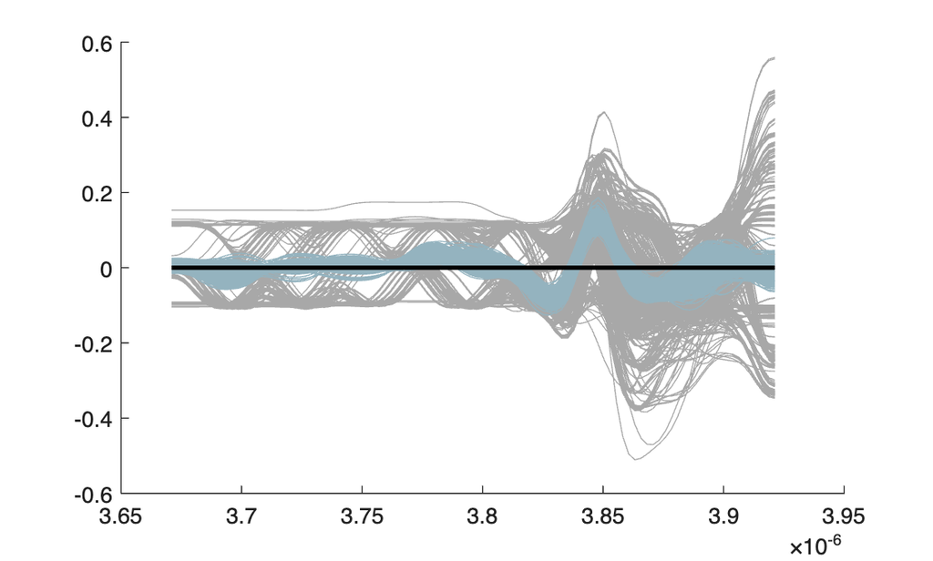

```matlab
figure()
clf
hold on
plot(time_new, vv_train', 'Color', [0.66,0.66,0.66])  %light grey
plot(time_new, vv_pred_obs', 'Color', [0.58,0.70,0.75])  %light blue
plot(time_new, vv_obs, 'k', 'Linewidth', 2)
```

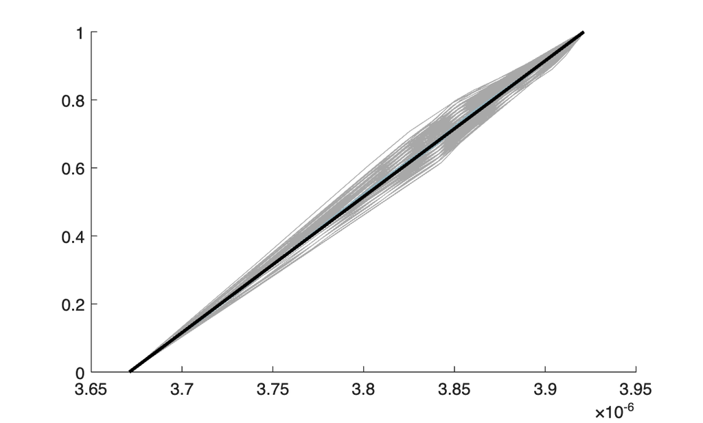

```matlab
figure()
clf
hold on
plot(time_new, gam_train, 'Color', [0.66,0.66,0.66])  %light grey
plot(time_new, gam_pred_obs', 'Color', [0.58,0.70,0.75])  %light blue
plot(time_new, gam_obs, 'k', 'Linewidth', 2)
```

We then combine the outputs of the emulators via composition to look at in the original data space

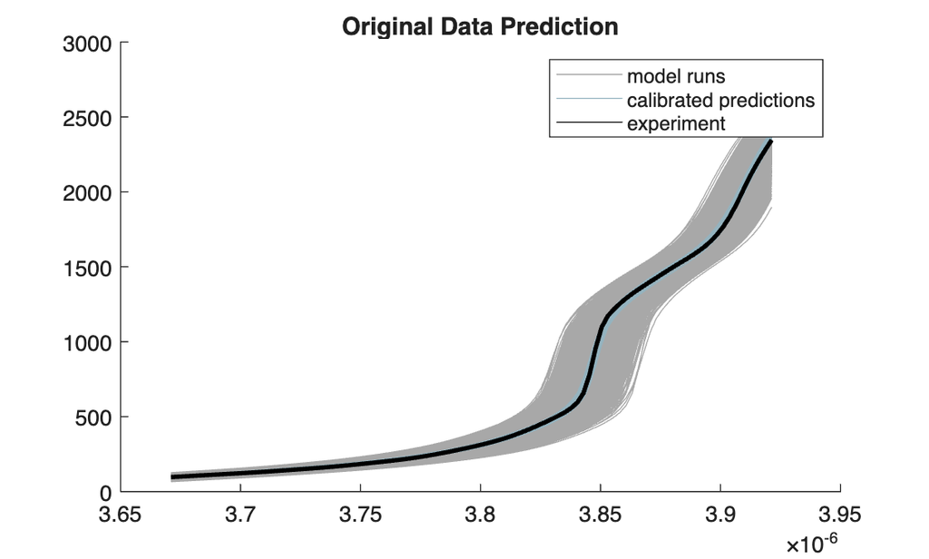

```matlab
obspred = zeros(M, length(uu));
for j = 1:length(uu)
    obspred(:,j) = warp_f_gamma(ftilde_pred_obs(j,:), invertGamma(gam_pred_obs(:,j)), tt);
end
figure()
clf
hold on
plot(time_new, f_sim(:,1), 'Color', [0.66,0.66,0.66])  %light grey
plot(time_new, obspred(:,1), 'Color', [0.58,0.70,0.75])  %light blue
plot(time_new, ftilde_obs, 'k')
plot(time_new, f_sim, 'Color', [0.66,0.66,0.66])  %light grey
plot(time_new, obspred, 'Color', [0.58,0.70,0.75])  %light blue
plot(time_new, ftilde_obs, 'k', 'Linewidth', 2)
title('Original Data Prediction')
legend('model runs','calibrated predictions','experiment')
```

## Sensitivity Analysis

First we will look at the amplitude surrogate

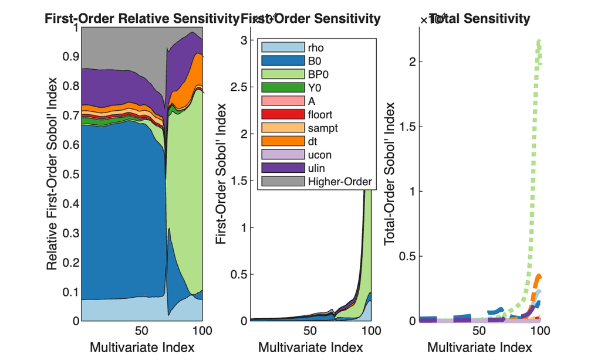

```matlab
emu_ftilde = mvSobol(emu_ftilde);
emu_ftilde.plotSobol('labels',input_names,'waterfall',true)
```

Next the phase surrogate

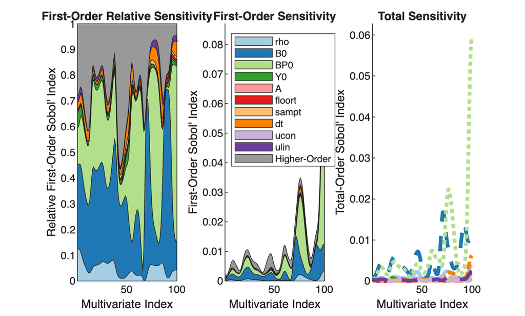

```matlab
emu_vv = mvSobol(emu_vv);
emu_vv.plotSobol('labels',input_names,'waterfall',true)
```